# 6.1 时间序列成分

使用乘法分解的一种替代方法是：首先对数据进行变换，直到时间序列随时间的波动趋于稳定，然后再使用加法分解。显然，采用对数变换的加法模型，等价于乘法模型： $y_{t} = S_{t} \times T_{t} \times R_t \quad\text{等价于}\quad \log y_{t} = \log S_{t} + \log T_{t} + \log R_t.$

# 电子设备生产

在本章中我们将会讲到获取时间序列成分 $S_{t}$,$T_{t}$和$R_{t}$的几种方法，但是在此之前，我们先来看一个例子。我们将分解如图 6.1 所示的电子设备新订单数量时间序列。数据显示了欧元区（16个国家）的电子设备（计算机、电子和光学产品）的新订单数量。数据已通过工作日调整并进行了正态化处理，使得100的值对应于2005。

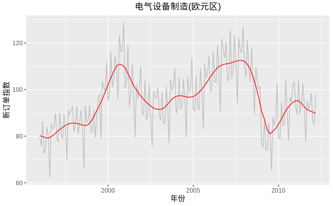

图 6.1: 电子设备订单量：趋势-周期成分（红色）和原始数据（灰色）。

如图 6.1 中的红色线表示趋势周期项$T_{t}$，灰色线表示原始数据$Y_{t}$。趋势周期项展示了序列的整体动态，忽略了季节性变动和其它随机波动。

图 6.2 展示了本条时间序列的加法分解。本例中运用了STL方法来估计时间序列的成分，我们将在章节 6.6 中详细讲解STL方法。

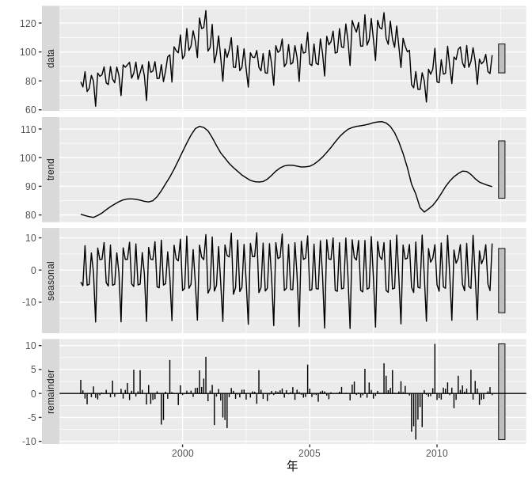

图 6.2: 电气设备订单（上）及其三个可加成分。

季节调整数据 如果将季节项从原始数据中剔除，可以得到经过“季节调整”后的数据。对于加法分解，季节调整数据的表达式为：$y_{t}-S_{t}$，对于乘法分解，季节调整数据可由$y_{t}/S_{t}$获得。

图 6.3 展示了季节调整后的电子设备订单数据。

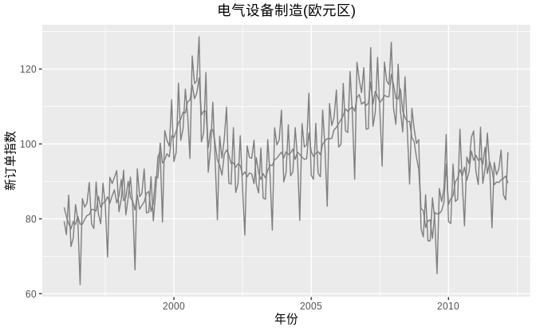

如果我们关心的不是季节性的数据波动，那么季节调整后的时间序列就会十分有用。例如，每月的失业率会受到季节性因素的影响，在学生离校的时期，当月失业率会显著上升，但这种失业率并不是由于经济衰退而导致的。因此，当研究经济和失业率的关系时，应该将失业率进行季节调整。大多数研究实业数据的经济分析学者对非季节性变化更感兴趣。因此，就业数据（和很多其他的经济数据）通常会经过季节调整。

经过季节调整后的时间序列既包含残差项也包含趋势周期项。因此，它们不太“平滑”，其“下转折”和“上转折”可能会有误导性。如果我们的目的是找到序列的转折点并解释方向的变化，那么相比于用季节调整后的数据，用趋势-周期项会更合适。